# Analytics Workflow for BikeShare

John Marot

# Overview

Within this document I will detail the analysis that I have completed to assist the theoretical company DownTown Bikes (DTB). I have provided the company with a model to predict the the total count of bike rentals each day. My analysis also offers DTB the opportunity to drill down and predict the number of casual (non-registered) rentals per day, as well as what variables are most important in predicting this value.

Due to maintenance costs and risk mitigation, it is advantageous for the DTB operations team to better predict the necessary amount of bikes to make available each day. To solve this problem, I utilized multiple regression analysis so that DTB can manage inventory more efficiently. Additionally, DTB’s marketing team is attempting to convert more casual riders into registered riders. Using my model, the marketing team can better predict which days attract the most casual riders and tailor promotions based on this.

### Package Management and Loading Data

I have utilized package management using the library pacman. If pacman is required and is not yet installed, it will install the package. Then by using pacman one can call all the required packages and they will be the same version as used in this analysis.

# Data Description

The source of this data set is the Capital BikeShare system which tracks over 500 different bike sharing programs and includes relevant attributes such as seasonal and weather information. The data analyzed includes the total count of riders by hour and day between the years 2011 and 2012.

- **Number of Observations:** *10,886*
- **Missing Observations:** *0*

### Variables

- **datetime:** hourly date + timestamp. Categorical, but will need to be split into two diferent numerical variables
- **season:**
  - 1 = spring
  - 2 = summer
  - 3 = fall
  - 4 = winter. Categorical. 4 levels
- **holiday:** whether the day is considered a holiday. Categorical. 2 levels
- **workingday:** whether the day is neither a weekend nor holiday. Categorical. 2 levels
- **weather:**
  - 1 = Clear, Few clouds, Partly cloudy, Partly cloudy
  - 2 = Mist + Cloudy, Mist + Broken clouds, Mist + Few clouds, Mist
  - 3 = Light Snow, Light Rain + Thunderstorm + Scattered clouds, Light Rain + Scattered clouds
  - 4 = Heavy Rain + Ice Pallets + Thunderstorm + Mist, Snow + Fog. Categorical. 4 levels
- **temp:** temperature in Celsius. Numerical
- **atemp:** “feels like” temperature in Celsius. Numerical
- **humidity:** relative humidity. Numerical
- **windspeed:** wind speed. Numerical
- **casual:** number of non-registered user rentals initiated. Numerical
- **registered:** number of registered user rentals initiated. Numerical
- **count:** number of total rentals initiated (casual + registered). Numerical

The following code includes a call for a data summary function and prints the head and tail of the data set.

```r
#Calling data summary function that is included within the github.
source('data summary.R')
data.summary(bikeshare)
```

```
##                   mean          sd  min      max  median length missing
## season       2.5066140   1.1161743 1.00   4.0000   3.000  10886       0
## holiday      0.0285688   0.1665989 0.00   1.0000   0.000  10886       0
## workingday   0.6808745   0.4661592 0.00   1.0000   1.000  10886       0
## weather      1.4184273   0.6338386 1.00   4.0000   1.000  10886       0
## temp        20.2308598   7.7915898 0.82  41.0000  20.500  10886       0
## atemp       23.6550841   8.4746006 0.76  45.4550  24.240  10886       0
## humidity    61.8864597  19.2450333 0.00 100.0000  62.000  10886       0
## windspeed   12.7993954   8.1645373 0.00  56.9969  12.998  10886       0
## casual      36.0219548  49.9604766 0.00 367.0000  17.000  10886       0
## registered 155.5521771 151.0390331 0.00 886.0000 118.000  10886       0
## count      191.5741319 181.1444538 1.00 977.0000 145.000  10886       0
##          levels          mode missing
## datetime  10886 1/1/2011 0:00       0
```

##### Head of the data frame:

```r
DT::datatable(head(bikeshare, 10))
```

|  | datetime | season | holiday | workingday | weather | temp | atemp | humidity | windspeed | casual | registered | count |
| --- | --- | --- | --- | --- | --- | --- | --- | --- | --- | --- | --- | --- |
| 1 | 1/1/2011 0:00 | 1 | 0 | 0 | 1 | 9.84 | 14.395 | 81 | 0 | 3 | 13 | 16 |
| 2 | 1/1/2011 1:00 | 1 | 0 | 0 | 1 | 9.02 | 13.635 | 80 | 0 | 8 | 32 | 40 |
| 3 | 1/1/2011 2:00 | 1 | 0 | 0 | 1 | 9.02 | 13.635 | 80 | 0 | 5 | 27 | 32 |
| 4 | 1/1/2011 3:00 | 1 | 0 | 0 | 1 | 9.84 | 14.395 | 75 | 0 | 3 | 10 | 13 |
| 5 | 1/1/2011 4:00 | 1 | 0 | 0 | 1 | 9.84 | 14.395 | 75 | 0 | 0 | 1 | 1 |
| 6 | 1/1/2011 5:00 | 1 | 0 | 0 | 2 | 9.84 | 12.88 | 75 | 6.0032 | 0 | 1 | 1 |
| 7 | 1/1/2011 6:00 | 1 | 0 | 0 | 1 | 9.02 | 13.635 | 80 | 0 | 2 | 0 | 2 |
| 8 | 1/1/2011 7:00 | 1 | 0 | 0 | 1 | 8.2 | 12.88 | 86 | 0 | 1 | 2 | 3 |
| 9 | 1/1/2011 8:00 | 1 | 0 | 0 | 1 | 9.84 | 14.395 | 75 | 0 | 1 | 7 | 8 |
| 10 | 1/1/2011 9:00 | 1 | 0 | 0 | 1 | 13.12 | 17.425 | 76 | 0 | 8 | 6 | 14 |

##### Tail of the data frame:

```r
DT::datatable(tail(bikeshare, 10))
```

|  | datetime | season | holiday | workingday | weather | temp | atemp | humidity | windspeed | casual | registered | count |
| --- | --- | --- | --- | --- | --- | --- | --- | --- | --- | --- | --- | --- |
| 10877 | 12/19/2012 14:00 | 4 | 0 | 1 | 1 | 17.22 | 21.21 | 50 | 12.998 | 33 | 185 | 218 |
| 10878 | 12/19/2012 15:00 | 4 | 0 | 1 | 1 | 17.22 | 21.21 | 50 | 19.0012 | 28 | 209 | 237 |
| 10879 | 12/19/2012 16:00 | 4 | 0 | 1 | 1 | 17.22 | 21.21 | 50 | 23.9994 | 37 | 297 | 334 |
| 10880 | 12/19/2012 17:00 | 4 | 0 | 1 | 1 | 16.4 | 20.455 | 50 | 26.0027 | 26 | 536 | 562 |
| 10881 | 12/19/2012 18:00 | 4 | 0 | 1 | 1 | 15.58 | 19.695 | 50 | 23.9994 | 23 | 546 | 569 |
| 10882 | 12/19/2012 19:00 | 4 | 0 | 1 | 1 | 15.58 | 19.695 | 50 | 26.0027 | 7 | 329 | 336 |
| 10883 | 12/19/2012 20:00 | 4 | 0 | 1 | 1 | 14.76 | 17.425 | 57 | 15.0013 | 10 | 231 | 241 |
| 10884 | 12/19/2012 21:00 | 4 | 0 | 1 | 1 | 13.94 | 15.91 | 61 | 15.0013 | 4 | 164 | 168 |
| 10885 | 12/19/2012 22:00 | 4 | 0 | 1 | 1 | 13.94 | 17.425 | 61 | 6.0032 | 12 | 117 | 129 |
| 10886 | 12/19/2012 23:00 | 4 | 0 | 1 | 1 | 13.12 | 16.665 | 66 | 8.9981 | 4 | 84 | 88 |

# Preprocessing

The first step was to separate datetime into a separate date column and numeric time column. This will allow for the inclusion of either date or time, if one wanted to perform a time series analysis on the data.

```r
bikeshare$Date <- sapply(strsplit(as.character(bikeshare$datetime), " "), "[", 1)
bikeshare$Time <- sapply(strsplit(as.character(bikeshare$datetime), " "), "[", 2)
bikeshare$Date <- as.Date(bikeshare$datetime,format='%m/%d/%Y')
bikeshare$Time <- as.factor(bikeshare$Time)
bikeshare$Time <- as.numeric(bikeshare$Time)

#Removing original datetime using select function in dplyr
bikeshare<-select(bikeshare, -datetime)
```

Next, it was necessary to re-code the variables season, holiday, workingday, and weather as factors. Following this, I added dummy variables for weather and season and appended these to the data frame.

```r
#recoding other variables as factors
bikeshare$season <- factor(bikeshare$season)
bikeshare$holiday <- factor(bikeshare$holiday)
bikeshare$workingday <- factor(bikeshare$workingday)
bikeshare$weather <- factor(bikeshare$weather)

#creating dummy variables for weather
dum1<-as.data.frame(model.matrix(~0+bikeshare$weather))
colnames(dum1)<-c("Clear", "Mist", "Light_SnowRain", "Heavy_SnowRain")
bikeshare<-cbind(bikeshare, dum1[,-1])

dum<-as.data.frame(model.matrix(~0+bikeshare$season))
colnames(dum)<-c("Spring", "Summer", "Fall", "Winter")
bikeshare<-cbind(bikeshare, dum[,-1])

#Removing original weather variable
bikeshare<-select(bikeshare, -weather)
bikeshare<-select(bikeshare, -season)
```

In terms of outlier removal, 3% of the observations were outliers. The outliers do not appear to be incorrectly measured data and do not affect model assumptions. Because of the relevance and variance provided from these observations I have decided to keep the outliers.

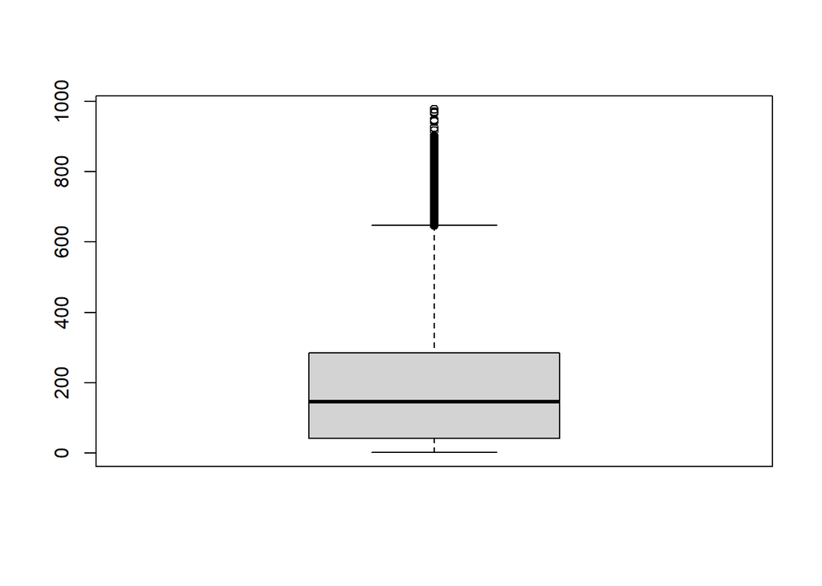

|

# Model Selection and Output

To avoid overfitting, I have partitioned the data. The code below involves setting the seed and splitting the data into the training set (70% of data) and the validation set (30% of data).

```r
set.seed(13)
trainIndex = sample(1:nrow(bikeshare), size = round(0.7*nrow(bikeshare)), replace=FALSE)

bikeshare.train<-bikeshare[trainIndex, ]
bikeshare.valid<-bikeshare[-trainIndex, ]
```

## Multiple Regression Analysis

The multiple regression model will be used to predict the overall count of riders, which is the sum of casual and registered rides. Therefore we need to take casual and registered out of the data frame for the analysis because they cannot be predictors for count.

```r
bikeshare.train<-select(bikeshare.train, -registered)
bikeshare.train<-select(bikeshare.train, -casual)
bikeshare.valid<-select(bikeshare.valid, -registered)
bikeshare.valid<-select(bikeshare.valid, -casual)
```

In addition to this, the data includes time variables such as date, time, and quarter. By looking at the plot below, one can see that there is significant monthly seasonality when looking at daily counts. To prevent the seasonality from affecting the model, I have removed the variables related to time.

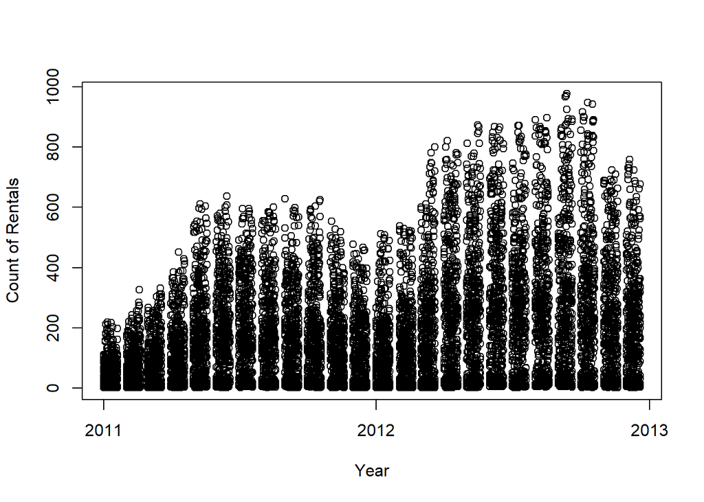

The below code includes the initial fitting of the model to all the available variables. The step-wise function then executes subsequently, using this full model as its upper range. Finally, the step-wise model outputs the optimal multiple regression equation and the values of the coefficients.

```r
#First fitting model with all variables available in training set
full<-lm(count~ .,data=bikeshare.train)


#Next using step-wise function to create multiple regression for total Count
null<-lm(bikeshare.train$count~1, data=bikeshare.train)
lm.step<-step(null, scope=list(lower=null, upper=full), direction="both", trace=0)

summary(lm.step)
```

```
##
## Call:
## lm(formula = bikeshare.train$count ~ humidity + Mist + atemp +
##     windspeed, data = bikeshare.train)
##
## Residuals:
##     Min      1Q  Median      3Q     Max
## -335.53 -102.05  -32.51   65.94  710.56
##
## Coefficients:
##             Estimate Std. Error t value Pr(>|t|)
## (Intercept) 159.7023     9.6744  16.508  < 2e-16 ***
## humidity     -2.7855     0.1014 -27.478  < 2e-16 ***
## Mist         20.9245     4.2297   4.947  7.7e-07 ***
## atemp         8.0221     0.2130  37.657  < 2e-16 ***
## windspeed     0.5793     0.2313   2.505   0.0123 *
## ---
## Signif. codes:  0 '***' 0.001 '**' 0.01 '*' 0.05 '.' 0.1 ' ' 1
##
## Residual standard error: 156.9 on 7615 degrees of freedom
## Multiple R-squared:  0.2404, Adjusted R-squared:   0.24
## F-statistic: 602.4 on 4 and 7615 DF,  p-value: < 2.2e-16
```

### Multiple Regression Evaluation

```
##                ME     RMSE      MAE       MPE    MAPE
## Test set 5.427377 158.8157 118.1528 -447.2096 480.269
```

## Regression Tree Analysis

The regression tree analysis was done to drill down into the count of casual riders. Before fitting the model, I needed to partition the data and remove count and registered because they will not be used in predicting casual rentals.

Initiating regression tree algorithm and printing the tree.

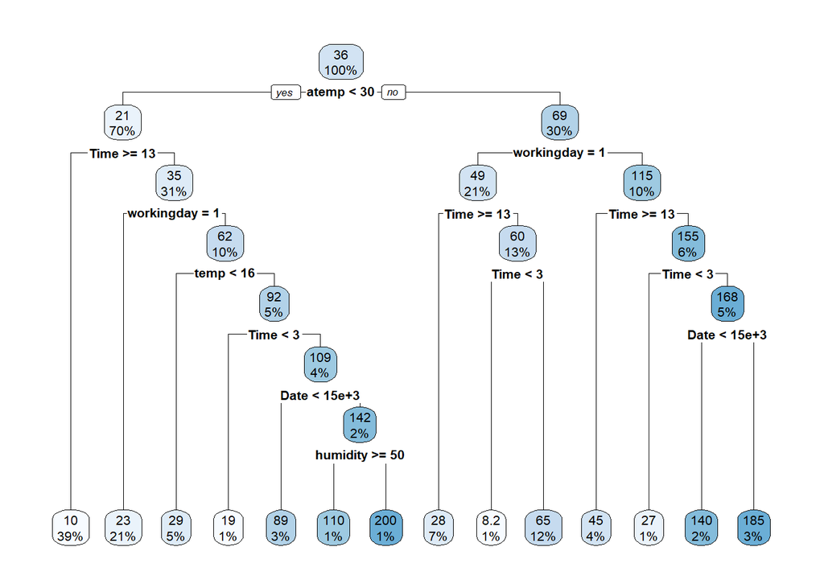

```r
m1 <- rpart(
  formula = casual ~ .,
  data    = bikeshare.train1,
  method  = "anova"
)
rpart.plot(m1)
```

|

Using the cv bagged model, I can cross validate the regression tree among different folds of the data.

```r
# Specify cross validation using 1o folds of data
ctrl <- trainControl(method = "cv",  number = 10)

# CV bagged model
bagged_cv <- train(
  casual ~ holiday + workingday + temp + humidity + windspeed,
  data = bikeshare.train1,
  method = "treebag",
  trControl = ctrl,
  importance = TRUE
)

# assess results
bagged_cv
```

```
## Bagged CART
##
## 7620 samples
##    5 predictor
##
## No pre-processing
## Resampling: Cross-Validated (10 fold)
## Summary of sample sizes: 6858, 6858, 6858, 6859, 6859, 6857, ...
## Resampling results:
##
##   RMSE      Rsquared  MAE
##   33.15287  0.545659  21.57461
```

Plotting the regressions tree determinance of importance among the different variables in the model.

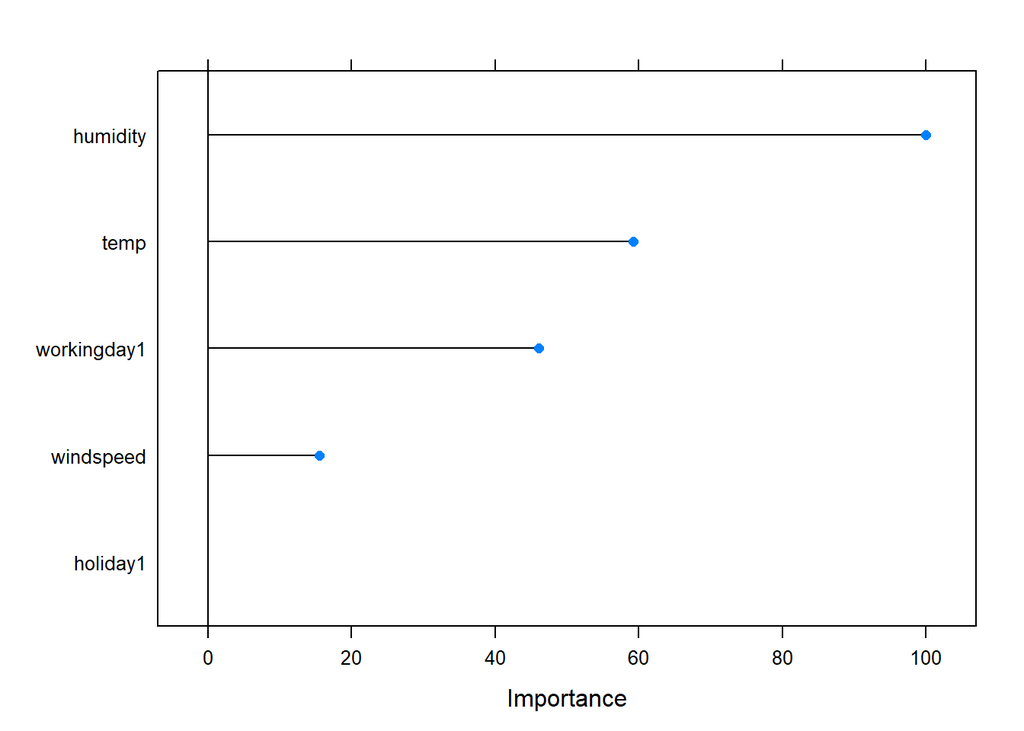

```r
# plot most important variables
plot(varImp(bagged_cv))
```

### Regression Tree Evaluation

As one can see, humidity, temperature, and workingday are the variables with the larest amount of importance within the regression tree analysis. Using this analysis to supplement the previous regression tree analysis for the casual count will allow the marketing team at DTB to have a better understanding of which days they should expect a large amount of casual bikers within the city. Additionally, according to the RMSE, one can predict that when using the regression tree the prediction for casual rentals will have an average error of 33.15 rentals.

# Conclusion